# Assignment 5

Kight Pruszynski

2025-12-11

## Assignment 5: Hierarchical Clustering

### Data preprocessing

**Load data and remove null cereals.**

```r
library(cluster) # agnes/diana
library(stats) # hclust

set.seed(123)

cereals <- read.csv("Cereals.csv")
cereals <- na.omit(cereals) # remove missing values
rownames(cereals) <- cereals$name # needed for plot labels downstream
head(cereals)
```

```
##                                                name mfr type calories protein
## 100%_Bran                                 100%_Bran   N    C       70       4
## 100%_Natural_Bran                 100%_Natural_Bran   Q    C      120       3
## All-Bran                                   All-Bran   K    C       70       4
## All-Bran_with_Extra_Fiber All-Bran_with_Extra_Fiber   K    C       50       4
## Apple_Cinnamon_Cheerios     Apple_Cinnamon_Cheerios   G    C      110       2
## Apple_Jacks                             Apple_Jacks   K    C      110       2
##                           fat sodium fiber carbo sugars potass vitamins shelf
## 100%_Bran                   1    130  10.0   5.0      6    280       25     3
## 100%_Natural_Bran           5     15   2.0   8.0      8    135        0     3
## All-Bran                    1    260   9.0   7.0      5    320       25     3
## All-Bran_with_Extra_Fiber   0    140  14.0   8.0      0    330       25     3
## Apple_Cinnamon_Cheerios     2    180   1.5  10.5     10     70       25     1
## Apple_Jacks                 0    125   1.0  11.0     14     30       25     2
##                           weight cups   rating
## 100%_Bran                      1 0.33 68.40297
## 100%_Natural_Bran              1 1.00 33.98368
## All-Bran                       1 0.33 59.42551
## All-Bran_with_Extra_Fiber      1 0.50 93.70491
## Apple_Cinnamon_Cheerios        1 0.75 29.50954
## Apple_Jacks                    1 1.00 33.17409
```

**Normalize data**

I had to ask for help scaling the nutrition values to serving size weight.

```r
nutrition_raw <- cereals[, 4:10] # extracting nutrition values from cereals dataset
nutrition_weighted <- sweep(nutrition_raw, 1, cereals$weight, "/") # scaling nutrition values by serving weight
nutrition <- scale(nutrition_weighted) # create matrix of normalized nutrition data using z-score
head(nutrition)
```

```
##                             calories    protein         fat     sodium
## 100%_Bran                 -2.4129312  1.4519505  0.04841078 -0.3150669
## 100%_Natural_Bran          1.1330137  0.5111438  4.11990590 -1.7199753
## All-Bran                  -2.4129312  1.4519505  0.04841078  1.2730903
## All-Bran_with_Extra_Fiber -3.8313092  1.4519505 -0.96946300 -0.1929010
## Apple_Cinnamon_Cheerios    0.4238247 -0.4296630  1.06628456  0.2957628
## Apple_Jacks                0.4238247 -0.4296630 -0.96946300 -0.3761499
##                                 fiber      carbo     sugars
## 100%_Bran                  3.38660475 -2.2621961 -0.1784615
## 100%_Natural_Bran         -0.03064593 -1.5513993  0.3127228
## All-Bran                   2.95944842 -1.7883316 -0.4240537
## All-Bran_with_Extra_Fiber  5.09523009 -1.5513993 -1.6520145
## Apple_Cinnamon_Cheerios   -0.24422409 -0.9590687  0.8039071
## Apple_Jacks               -0.45780226 -0.8406026  1.7862757
```

### Apply hierarchical clustering

**Agnes**

```r
hc_single <- agnes(nutrition, method = "single")
hc_complete <- agnes(nutrition, method = "complete")
hc_average <- agnes(nutrition, method = "average")
hc_ward <- agnes(nutrition, method = "ward")

print(hc_single$ac)
```

```
## [1] 0.6878427
```

```r
print(hc_complete$ac)
```

```
## [1] 0.8851994
```

```r
print(hc_average$ac)
```

```
## [1] 0.8288271
```

```r
print(hc_ward$ac) # Best defined clustering (.92)
```

```
## [1] 0.9175011
```

**Plot Ward dendrogram**

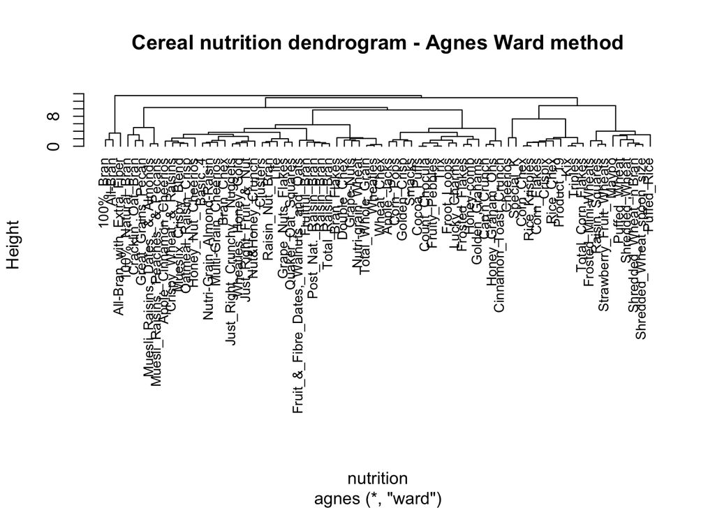

```r
pltree(hc_ward, cex = 0.8, hang = -1, main = "Cereal nutrition dendrogram - Agnes Ward method")
```

**How many clusters would you choose?**

I want to cut my Ward dendrogram at a height of 6, achieving six clusters. I tried four and five clusters, but six divides a very large cluster into two more insightful clusters, one of which appears (at first glance) to be cereals typically known as high sugar but otherwise low nutritional value. I’d want to explore this further.

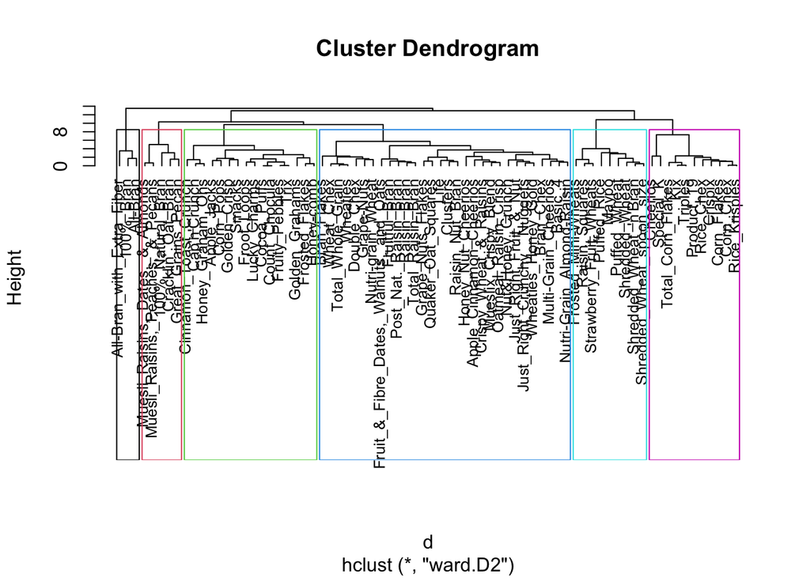

```r
d <- dist(nutrition, method = "euclidean")
ward <- hclust(d, method = "ward.D2") # base r (stats) ward.D2
plot(ward, cex = .8, hang = -1)
rect.hclust(ward, k = 6, border = 1:6)
```

### Validate Clusters

**Mean nutritional values by cluster**

While analyzing the mean nutritional values by cluster, I realized that I inadvertently excluded potassium and vitamins from the nutrition dataframe that I used for clustering. I’m too far in now to go back and correct for that.

Cluster 1 = High satiety cereals (low calorie, high protein, high fiber) Cluster 2 = Granola (high fat, high calorie) Cluster 3 = Plain cereal (low sugar) Cluster 4 = Sugary cereal (low protein, low fiber, high sugar) Cluster 5 = Starchy cereal (high sodium, high carbohydrates, low fiber, low sugar) Cluster 6 = Natural cereal (low sodium, low sugar)

```r
cluster_labels <- cutree(ward, k=6) # assign cluster labels
aggregate(nutrition, by = list(cluster = cluster_labels), FUN = mean) # means of nutrition features by cluster
```

```
##   cluster   calories     protein         fat      sodium       fiber      carbo
## 1       1 -2.8857239  1.45195051 -0.29088048  0.25504078  3.81376109 -1.8673090
## 2       2  1.8422026  0.88746647  2.49130785 -0.74264774  0.39651041 -0.4615110
## 3       3 -0.2111913  0.08420216  0.06471403  0.15668334  0.15010673 -0.2303870
## 4       4  0.5124733 -1.07646759 -0.01520633  0.06670162 -0.72477497 -0.5296290
## 5       5  0.2948812  0.25456012 -0.50679310  1.28419627 -0.65196423  1.3994842
## 6       6 -0.6290409  0.34489680 -0.85636591 -1.88286318  0.09344099  0.8778699
##          sugars
## 1 -0.7515099098
## 2  0.3618412138
## 3 -0.0002213822
## 4  1.3257904404
## 5 -1.0045442561
## 6 -1.0789661227
```

**Ratings by cluster**

I was curious to see if there was any pattern to the ratings by cluster. I don’t know what the ratings measure, though. Is this rating for nutrition by the FDA? Rating by how much kids prefer the cereals? It’s a little arbitrary without that clarification, but since sugary cereals rank lowest, I will assume that the ranking is based on nutrition in some way.

Cluster 1 = High satiety cereals = 74 (rank 1) Cluster 2 = Granola = 38 (rank 5) Cluster 3 = Plain cereal = 41 (rank 4) Cluster 4 = Sugary cereal = 27 (rank 6) Cluster 5 = Starchy cereal = 44 (rank 3) Cluster 6 = Natural cereal = 63 (rank 2)

```r
cereals$cluster <- cluster_labels
aggregate(cereals$rating, by = list(cluster = cluster_labels), FUN = mean)
```

```
##   cluster        x
## 1       1 73.84446
## 2       2 38.30416
## 3       3 41.23096
## 4       4 27.43835
## 5       5 43.57727
## 6       6 63.01840
```

**Validate for stability**

I needed help with this.

```r
set.seed(123)

# partition data
n <- nrow(nutrition)
idx <- sample(seq_len(n), size = floor(.5*n)) # 50% (I didn't know a way to do it for unsupervised.)

a <- nutrition[idx,] # partition A
b <- nutrition[-idx,] # partition B

# do ward again on partition A
da <- dist(a, method = "euclidean")
ward_a <- hclust(da, method = "ward.D2")
cluster_a <- cutree(ward_a, k = 6)

# find centroids for A
centroids_a <- aggregate(a, by = list(cluster_a), FUN=mean)
centroids_a <- as.matrix(centroids_a[,-1]) # drop the cluster names I put in earlier

head(centroids_a)
```

```
##        calories    protein         fat      sodium      fiber      carbo
## [1,] -0.2853643  0.9143467 -0.38782084  0.39175028  0.3965104  0.1748214
## [2,] -0.4147602  0.0240464  0.34096658  0.01146210  0.3709024 -0.9529762
## [3,]  0.4947436 -1.0882277  0.04841078 -0.06462677 -0.7995273 -0.5088974
## [4,]  0.4238247 -0.4296630 -0.20605767  1.12038285 -0.8849586  1.5879530
## [5,] -0.6399588  0.7463455 -0.71499456 -1.90322417  0.1829322  0.6402240
## [6,]  3.2605806  1.4519505  2.08415834 -0.40669140  0.3965104  0.3440587
##          sugars
## [1,] -0.5643921
## [2,]  0.4335492
## [3,]  1.3196506
## [4,] -0.9152380
## [5,] -1.0380341
## [6,]  1.0494993
```

### Conclusion

I couldn’t finish validating. I try referring to the Validating Clusters section of Chapter 15 and the class slides but can’t seem to understand how to do this correctly with an unsupervised method. I will keep trying but need to get this to you for the deadline.

I scaled the nutritional values to portion size and normed them with z-score. I tried agnes and found ward to be the tightest clustering method. I tried 4, 5, and 6 clusters on the dendrogram and found 6 gave me the most meaningful clusters. My first cluster, which I call High Satiety Cereals, is also ranked highest in the dataset. I’m assuming the ranking is a nutritional values ranking of some sort. My cluster 6 is Natural Cereals and ranked 2nd. I would need to spend more time with this data to better understand it and validate my findings before making a recommendation to the district.